# What Does a Buoy in Southern Bering Sea Tell Us?

March 15, 2018

## Background

Is global warming serious?

We acquired 30 years time series data of a buoy (No.46035 at 57.026 N 177.738 W) in southern Bering Sea from NOAA (National Oceanic and Atmospheric Administration) National Data Buoy Center.

And we look at them.

Then we ask:

- Are air temperature and sea temperature related?
- Has tmeperature changed over the past 30 years?

## Issues in real data

- Two digits 'year' until 1998; four digits 'year' starts from 1999
- Time precision enhanced to 'minutes' from 2005/01/01
- From 2008/01/31 23:00, all data collected at XX:50, like 00:50 instead of 01:00
- Data of 2013 are all missing
- From 2007, the second row is unit: one more line to skip when reading
- ATMP (Air Temperature) and WTMP (Sea Temperature) has missing values displayed as '99' and '999'

## Solution to issues

- 1988-1998, turn year to 4 digits
- 1988-2004, suppose minute = 00:00 before minute precision was reached
- 2005-2006, when reading ATMP and WTMP, shift one column rightward
- 2007-2017, read from 3rd line to skip unit line; when reading ATMP and WTMP, shift one column rightward
- Make a 10-minutes approximate shift at 2008/01/31 23:50 -> 2008/02/01 00 and from then on all data shift by 10 minutes forward.
- Detect and assign all missing value with 'NA'

## Special issue we identified

- WTMP 'jumped' back and forth from 9.9 to 0.0 during certain years. (e.g. 8.9 -> 9.9 -> 0.0 -> 0.1 -> 0.0 -> 9.9)
- 2004-2006

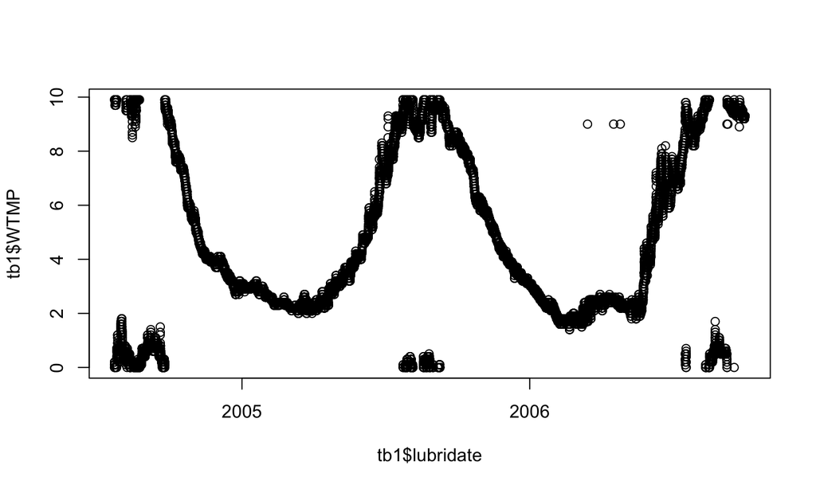

## Special issue we identified

- WTMP 'jumped' back and forth from 9.9 to 0.0 during certain years. (e.g. 8.9 -> 9.9 -> 0.0 -> 0.1 -> 0.0 -> 9.9)
- 2015-2017

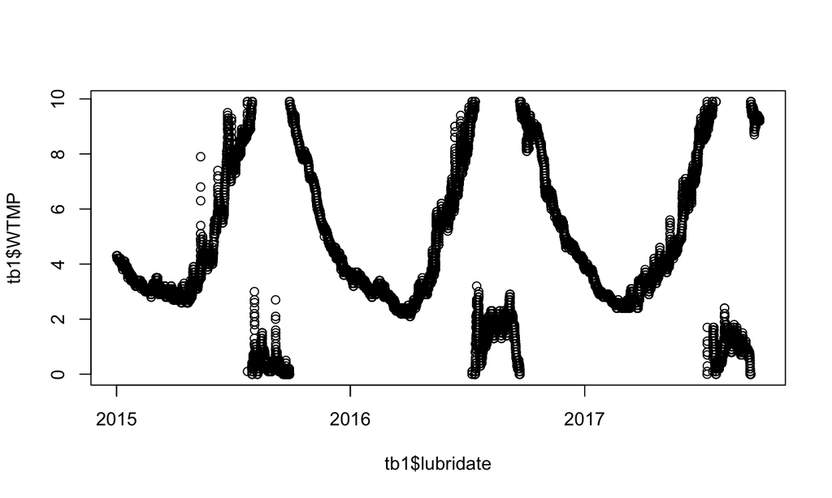

## Solution to issue

We identify the outliner and fix it

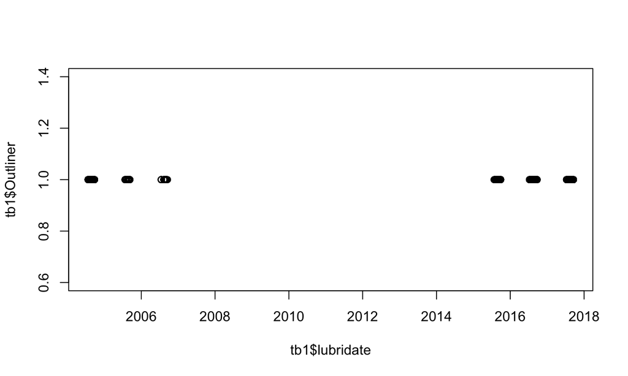

## Cleaned tidy data

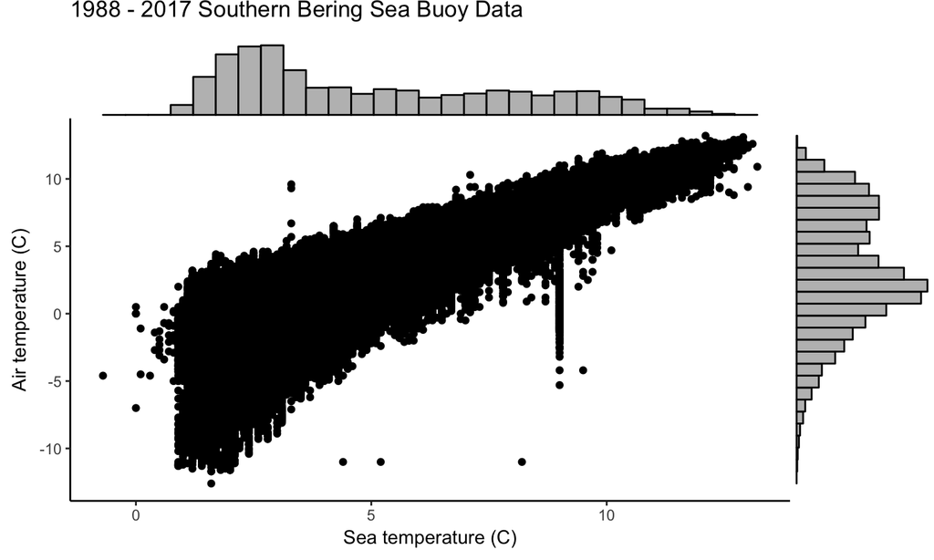

## Cleaned tidy data

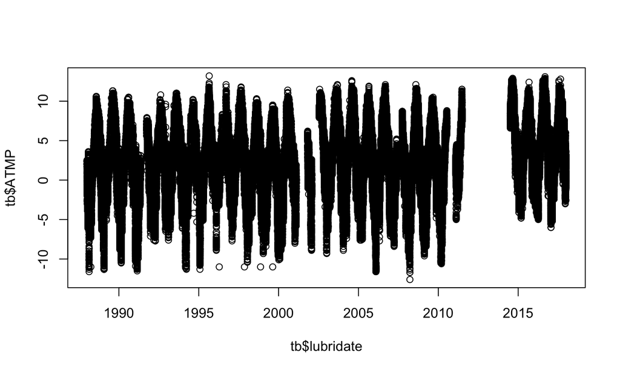

## Cleaned tidy data

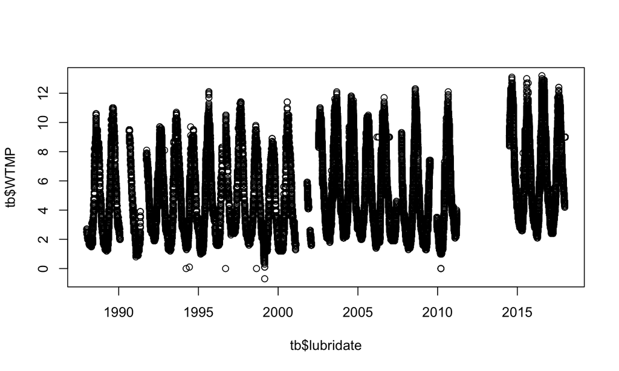

## Cleaned tidy data

```
## # A tibble: 228,517 x 3
##    lubridate            ATMP  WTMP
##    <dttm>              <dbl> <dbl>
##  1 1988-01-01 02:00:00  2.00  2.70
##  2 1988-01-01 03:00:00  1.70  2.70
##  3 1988-01-01 04:00:00  2.00  2.70
##  4 1988-01-01 05:00:00  2.40  2.70
##  5 1988-01-01 06:00:00  2.40  2.70
##  6 1988-01-01 07:00:00  2.40  2.70
##  7 1988-01-01 08:00:00  2.50  2.70
##  8 1988-01-01 09:00:00  2.40  2.60
##  9 1988-01-01 10:00:00  2.00  2.50
## 10 1988-01-01 11:00:00  2.10  2.50
## # ... with 228,507 more rows
```

## Statistical Analysis

To test whether air temperatuer and sea temperature are related, we use simple linear regression.

To test whether air temperatuer or sea temperature is trending upward, we use seasonal linear regression, a parametric trend testing method with period n assigned (e.g. 12 for monthly data, 52 for weekly data). The advantage of this method is that it can minimize the loss of values. If there is no trend, the linear term would be zero, though there exist missing values.

\[ {Y_t}= {\beta_0}+{\beta_1}\sin(\frac{2\pi}{n}\cdot t)+{\beta_2}\cos(\frac{2\pi}{n}\cdot t) + {\beta_3}t + {\epsilon_t} \]

\[t = 1, 2, 3,...\]

The result would be displayed in Shiny App.